# Compte rendu de TP

Arthur Zucker

11/26/2019

# Introduction

Nous allons utiliser la base de données ozone vu au TP précedent.

Les $y$ que nous utiliserons sont les concentration en ozone : `max03`, et nous l’évaluerons en fonction de $x$, la température à midi notée `T12`.

## Question 1

Représentons un nuage de point de $y$ en fonction de $x$.

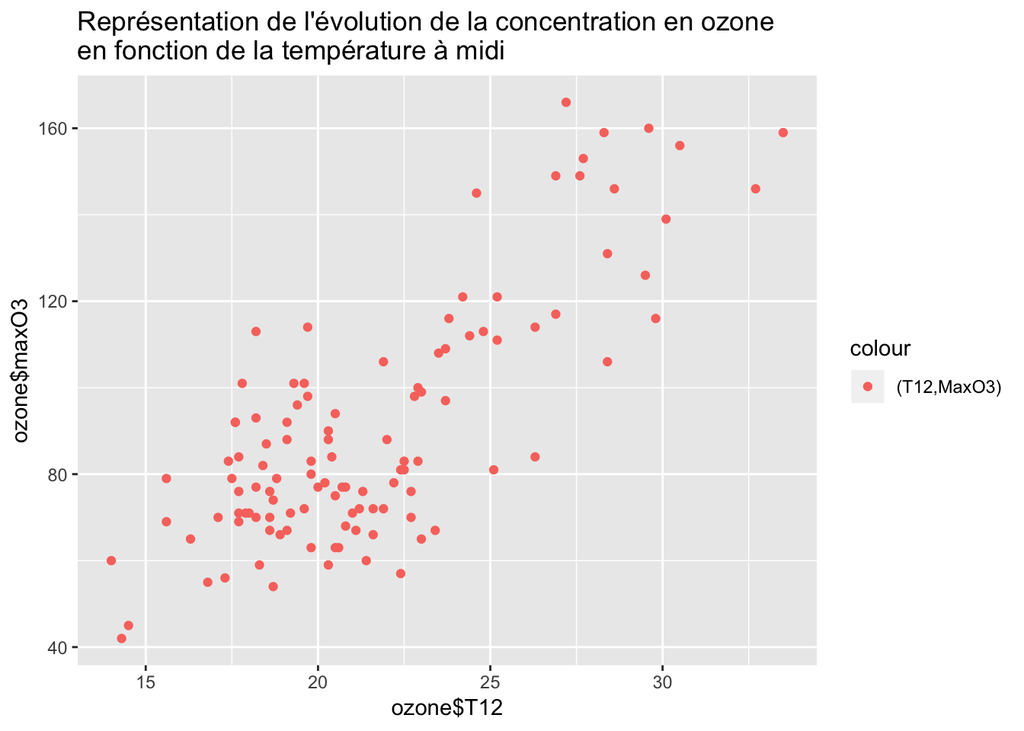

Ici, les donnée sont répartie de manière plutôt linéaire, même si elles sont très espacées. On peut donc utiliser un modèle de régression linéaire que nous allons calculer avec la commande `lm()`.

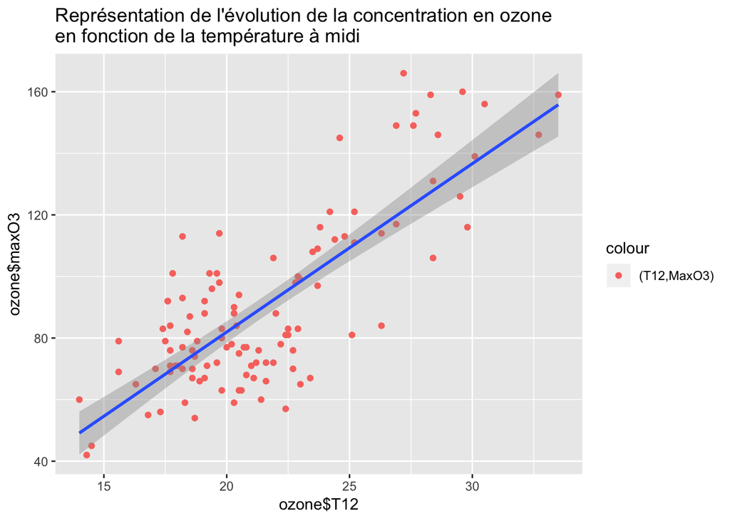

## Question 3

L’intervalle de confiance pour $a$ peut être extrait en utilisant la fonction `confint()res` :

```r
confint(res)
```

```
##                  2.5 %    97.5 %
## (Intercept) -45.321901 -9.517371
## T12           4.651219  6.286151
```

Cette sortie nous donne l’intervalle : $IC_{a}^{95\%} = [-45.32;-9.51]$ on observe que $0\notin IC$ ce qui nous permet de rejetter l’hypothèse $H_{0}$ selon laquelle $a=0$ avec un risque de se tromper de $5\%$.

Pour b on a $IC_{a}^{95\%} = [4.6;6.2]$ on observe que $0\notin IC$ ce qui nous permet de rejetter l’hypothèse $H_{0}$ selon laquelle $b=0$ avec un risque de se tromper de $5\%$.

## Question 4

1. Test de student :

On utilise la **t-value** donnée dans le summary de res. On la compare avec le quantile d’ordre $1-\alpha$. Et on en déduit si on accepte ou rejette l’hypothèse. On récupère tout d’abord les p-value. t-value c’est $T_{\text{obs}}$

```r
summary(res)$coefficients[,3]
```

```
## (Intercept)         T12
##    -3.03533    13.25761
```

Ensuite on calcul la valeur du quantile :

```r
n = length(maxO3)
alpha = 0.05
qt(1-alpha/2,n-2)
```

```
## [1] 1.981765
```

2. IC ou p-value :

On peut directement utiliser la p-value donnée dans les coefficients. Ici on a

```r
summary(res)$coefficients[,4]
```

```
##  (Intercept)          T12
## 2.999431e-03 1.512025e-24
```

Donc pour $\alpha = 0.05$ on rejette $H_{0}$.

3. Test de Fisher :

On utilise le quantile de ficher cette fois ci. On récupère la F-statistic sur le res :

```r
summary(res)
```

```
##
## Call:
## lm(formula = maxO3 ~ T12, data = ozone)
##
## Residuals:
##     Min      1Q  Median      3Q     Max
## -38.079 -12.735   0.257  11.003  44.671
##
## Coefficients:
##             Estimate Std. Error t value Pr(>|t|)
## (Intercept) -27.4196     9.0335  -3.035    0.003 **
## T12           5.4687     0.4125  13.258   <2e-16 ***
## ---
## Signif. codes:  0 '***' 0.001 '**' 0.01 '*' 0.05 '.' 0.1 ' ' 1
##
## Residual standard error: 17.57 on 110 degrees of freedom
## Multiple R-squared:  0.6151, Adjusted R-squared:  0.6116
## F-statistic: 175.8 on 1 and 110 DF,  p-value: < 2.2e-16
```

```r
qf(1-alpha,1,110)
```

```
## [1] 3.927394
```

Ici on a $F = 175.8>3.92$

## Question 5

```r
0.5*summary(res)$coefficients[1,4]
```

```
## [1] 0.001499716
```

On rejette donc $H_{0}$.

## Question 6``

1. Test de student

Ici on effectue un test bilatéral pour $H_{0}:a = 0$ et $H_{1} : a \neq 0$. La p-value est donnée par le quantile :

```r
qt(1-alpha/2,n-2)
```

```
## [1] 1.981765
```

```r
summary(res)$coefficients[1,3]
```

```
## [1] -3.03533
```

Ici on a $|-3|>1.98$ don con rejette $H_{0}$.

2. Intervalle de confiance

Déjà répondu précédemment

## Question 7

a,b,c) On peut faire une prédiction ponctuelle, ou une prédiction avec intervalle de confiance. L’espérence de $y_{19}$ prend un modèle parfait, sans bruits. L’IC de $y_{19}$ sera plus grand que l’IC de $E(y_{19})$. On utilise les valeurs de $\hat{a}$ et $\hat{b}$ pour prédire “à la main” la valeur de $y_{19}$.

$E(y_{19}) = a +19b$ et $y_{19} = a+19*b +\epsilon$

d,e) On rentre les commandes proposées

```r
predict19esp<-predict(res,newdata = data.frame(T12=19),interval = "confidence")
predict19e<-predict(res,newdata = data.frame(T12=19),interval = "prediction") # Avec bruit
```

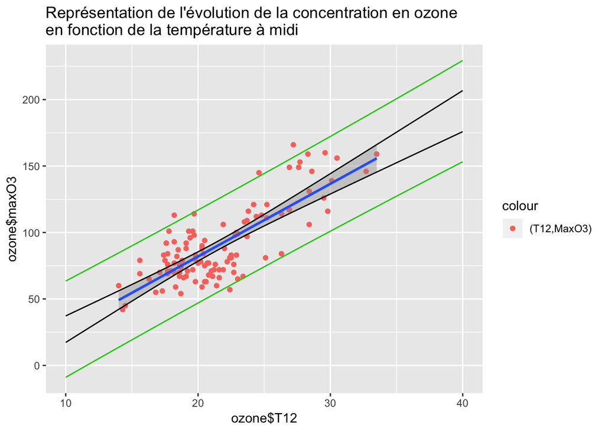